# Mechano-Genomic Score

## Background and Aim

The packing of the genome within the nucleus informs the cellular state. Therefore, changes in DNA packing information would be a powerful barometer of cell state transitions in important processes such as cancer progression, where there is an unmet need for biomakers. The gold standard for cell abnormalities in cancer is the nuclear grading done by a pathologist using a microscope. High resolution images of DNA as visualised using a fluorescent microscope is a convenient tool to measure DNA organization and build a quantitative framework for cell state transitions.

Our samples are obtained from tissue microarray (TMA) slides containing annotated clinical biopsies from cancer patients as well as healthy individuals stained for DNA using Hoechst. Segmentation and feature extraction was carried out in python. We have obtained morphometric and texture features for every single nucleus in a given tissue microarray.

Our goal now is to reduce the dimensionsality of the feature space such that we obtain a score that is different for cancer and normal nuclei. In this exercise we aim to find out if we label all nuclei from a normal tissue as “normal” and all nuclei from a cancerous tissue as “cancer”, can we reliably distinguish between the two at the single cell level. Note that since we do not have the ground truth information at the single cell level, we do not expect very high levels of accuracies at the single cell level, but we expect that the majority of the nuclei in the tissue will be faithfully predicted.

### Preprocessing data

Once we read in all the data, we drop some uninformative columns such as centroids, orientation, etc and features with constant values and remove nuclei that do not adhere to the following conditions.

- Area is between 30-5000 (~2-300 sq.microns)
- Median intensity is at least 10
- Standard deviation of intensity is at least 2

The above filters will make sure that very small or very large nuclei or nuclei that are under exposed or fully saturated or out of focus are not included in the analysis. This filter will also remove small objects with very uniform texture such as mitotic nuclei. Hence, after the filtration, we expect to have proper interphase nuclei.

[output not shown]

Below is a summary of the dataset we are working with.

Dataset

| stages_of_cancer | numb_tissues | numb_nuc_before_filtering | numb_nuc_after_filtering |
| --- | --- | --- | --- |
| Normal | 7 | 46658 | 45989 |
| Hyperplasia | 15 | 94557 | 92160 |
| Fibroadenoma | 7 | 27979 | 26602 |
| DCIS | 10 | 68636 | 61536 |
| ILC | 9 | 62538 | 57383 |
| IDC | 16 | 93151 | 82800 |
| Metastasis | 13 | 93636 | 78359 |

## Scoring system for distinguishing normal and cancer nuclei

We scale the data and then PCA to reduce dimensionality and maybe regularise the data.

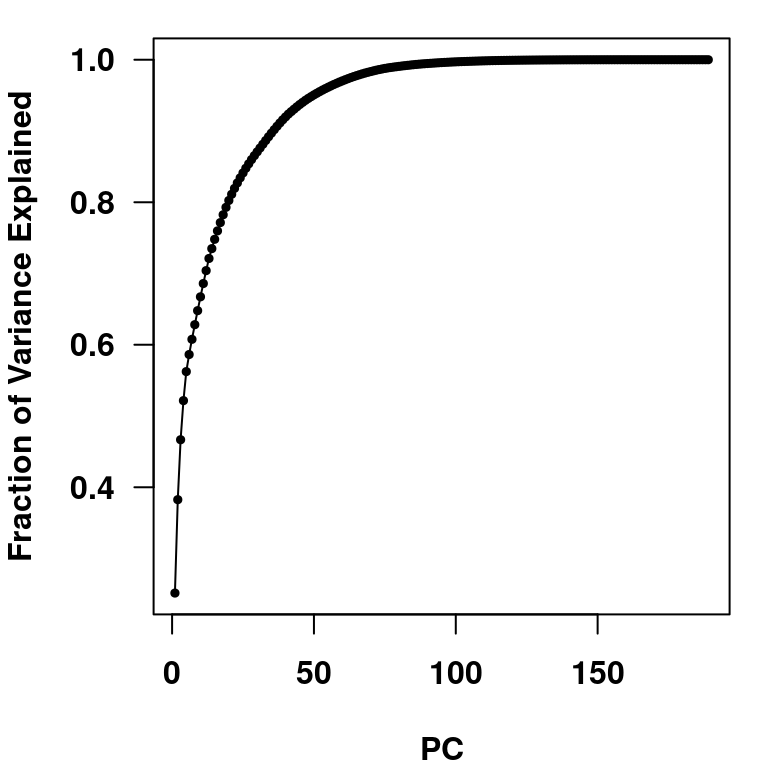

Normal nuclei are obtained from TMAs whose clinical diagnosis is “Normal Breast Tissue” and “Hyperplasia”. Cancer nuclei are obtained from TMAs whose clinical diagnosis is “Invasive Ductal Carcinoma” and “Invasive Lobular Carcinoma”.

### Measuring prediction error of the model

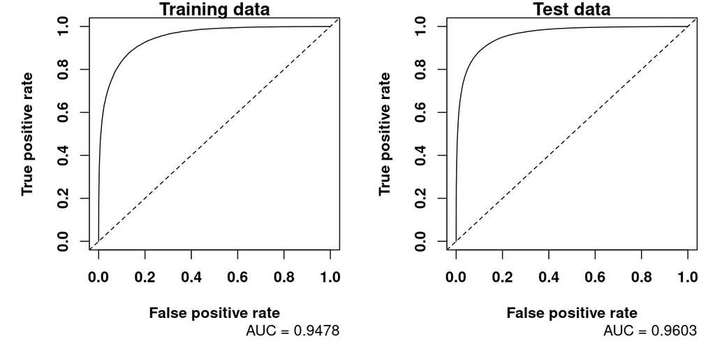

Printing model contingency tables.

```
## [1] "Training"
```

```
##           Reference
## Prediction Cancer Normal
##     Cancer  21359   2990
##     Normal   3284  21653
```

```
## [1] "Test"
```

```
##           Reference
## Prediction Cancer Normal
##     Cancer 103358  12578
##     Normal  12182 100928
```

Below are some features that assess the validity of the model.

|  | Training | Test |
| --- | --- | --- |
| Sensitivity | 0.8667370 | 0.8945647 |
| Specificity | 0.8786674 | 0.8891865 |
| Pos Pred Value | 0.8772023 | 0.8915091 |
| Neg Pred Value | 0.8683081 | 0.8922995 |
| Precision | 0.8772023 | 0.8915091 |
| Recall | 0.8667370 | 0.8945647 |
| F1 | 0.8719383 | 0.8930343 |
| Prevalence | 0.5000000 | 0.5044402 |
| Detection Rate | 0.4333685 | 0.4512543 |
| Detection Prevalence | 0.4940348 | 0.5061691 |
| Balanced Accuracy | 0.8727022 | 0.8918756 |
| AUC_ROC | 0.9478117 | 0.9603199 |

To test the generalizability of the training, we computed K-fold cross validation error (Standard Deviation) of the above model robustness features(k=30).

K-fold Cross-Validation

|  | Mean | StdDev |
| --- | --- | --- |
| Sensitivity | 0.8660702 | 0.0108906 |
| Specificity | 0.8779815 | 0.0113626 |
| Pos Pred Value | 0.8764192 | 0.0126092 |
| Neg Pred Value | 0.8675187 | 0.0126214 |
| Precision | 0.8764192 | 0.0126092 |
| Recall | 0.8660702 | 0.0108906 |
| F1 | 0.8711458 | 0.0088982 |
| Prevalence | 0.4999997 | 0.0136732 |
| Detection Rate | 0.4330028 | 0.0119446 |
| Detection Prevalence | 0.4940344 | 0.0105945 |
| Balanced Accuracy | 0.8720258 | 0.0085705 |
| AUC | 0.9471907 | 0.0050862 |

### Mechano-Genomic score for discriminating normal and cancer nuclei

Below we visualise the linear discriminant in the two tissue conditions

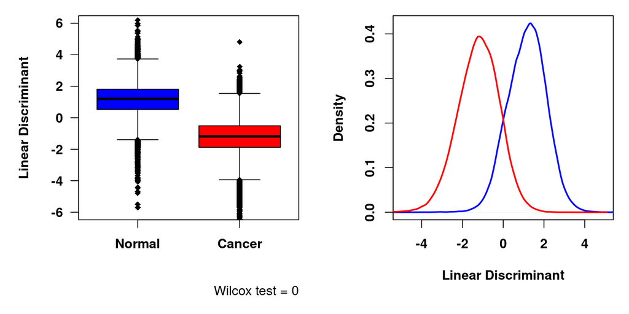

We then compute a mechanogenomic score from the linear discriminant as follows:
$$MGS(i) =
\begin{cases}
\frac{LD(i)-min(LD)}{max(LD)-min(LD)},& \text{if } -4\leq LD(i)\leq 4\\
\frac{-4 -min(LD)}{max(LD)-min(LD)},& \text{if } LD(i)< -4\\
\frac{4 -min(LD)}{max(LD)-min(LD)},& \text{if } LD(i)> 4\\
\end{cases}$$

The rational is to avoid extreme values by setting a minimum and maximum limit for the linear discriminant (LD) and to reset the range between 0-1. We set the limits of LD to be between -4 and 4 as most of the values of LD1 exist within this range (see above for distribution and below for the the exact fraction).

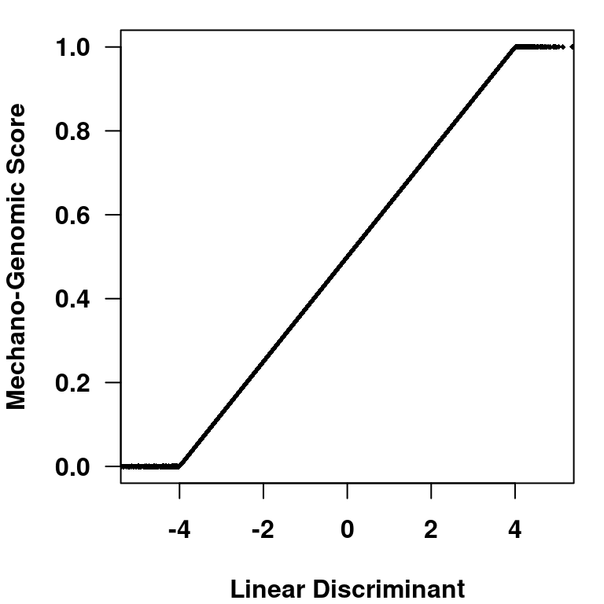

```
## [1] "Fraction of nuclei with LD between -4 and 4 is 0.9961"
```

Below we visualise the Mechano-Genomic Scores in the two tissue conditions

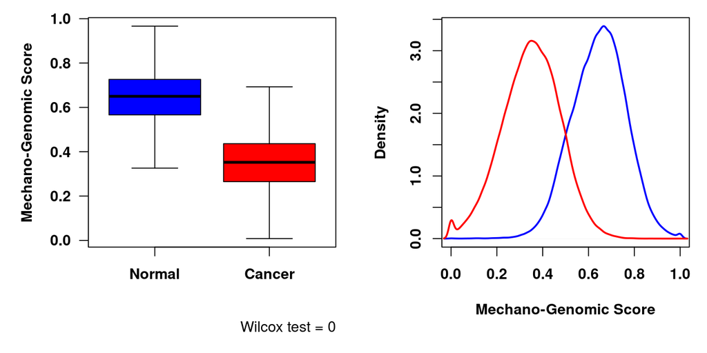

### Comprehending the Mechanogenomic score

In order to understand what features the contribute most to the MGS, we computed the correlation coefficient between MGS and all the Nuclear Morphometric and Chromatin Organization Features for nuclei from normal and invasive cancer TMA. PCC: Pearson Correlation Coefficient SRC: Spearman Rank Correlation

Below is a heatmap showing the correlation for all features.

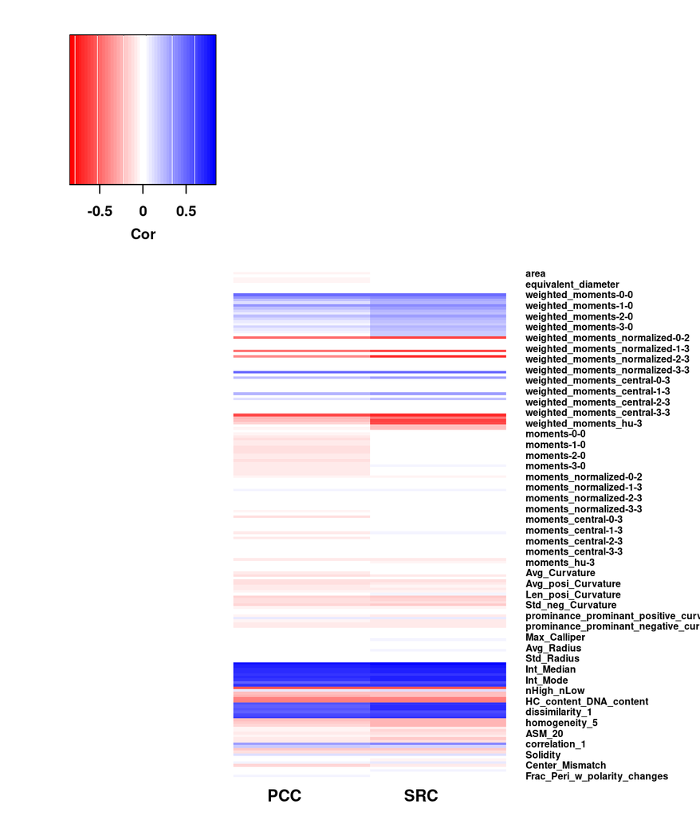

Below are the top 30 features.

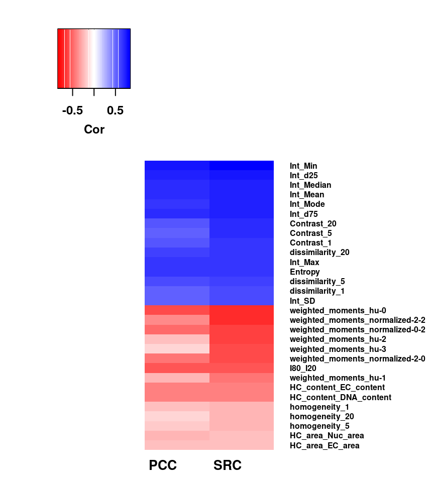

[figure not shown]

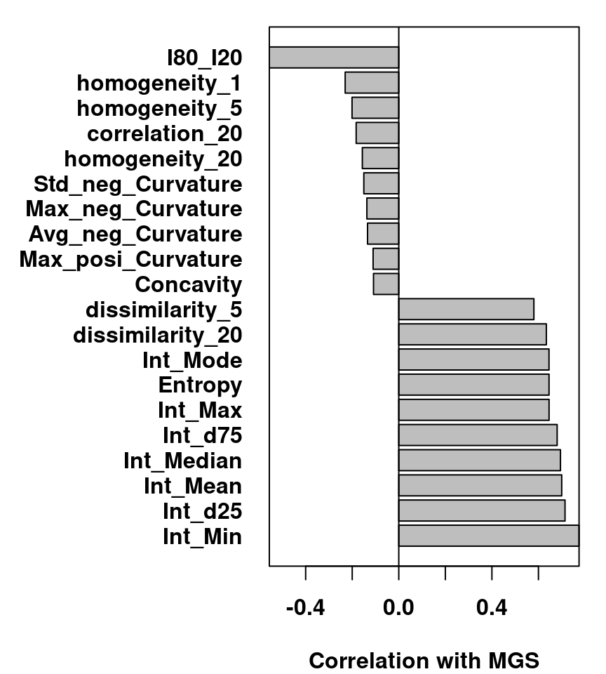

```r
columns_to_drop_not_interpreatble<-c("weighted_moments-0-0", "weighted_moments-0-1",
                                      "weighted_moments-0-2","weighted_moments-0-3",
                                     "weighted_moments-1-0", "weighted_moments-1-1",
                                      "weighted_moments-1-2","weighted_moments-1-3",
                                     "weighted_moments-2-0", "weighted_moments-2-1",
                                      "weighted_moments-2-2","weighted_moments-2-3",
                                     "weighted_moments-3-0", "weighted_moments-3-1",
                                      "weighted_moments-3-2","weighted_moments-3-3",
                            "weighted_moments_central-0-0", "weighted_moments_central-0-1",
                            "weighted_moments_central-0-2","weighted_moments_central-0-3",
                          "weighted_moments_central-1-0", "weighted_moments_central-1-1",
                            "weighted_moments_central-1-2","weighted_moments_central-1-3",
                          "weighted_moments_central-2-0", "weighted_moments_central-2-1",
                          "weighted_moments_central-2-2","weighted_moments_central-2-3",
                          "weighted_moments_central-3-0", "weighted_moments_central-3-1",
                          "weighted_moments_central-3-2","weighted_moments_central-3-3",
                          "weighted_moments_normalized-0-0", "weighted_moments_normalized-0-1",
                          "weighted_moments_normalized-0-2","weighted_moments_normalized-0-3",
                          "weighted_moments_normalized-1-0", "weighted_moments_normalized-1-1",
                          "weighted_moments_normalized-1-2","weighted_moments_normalized-1-3",
                          "weighted_moments_normalized-2-0", "weighted_moments_normalized-2-1",
                          "weighted_moments_normalized-2-2","weighted_moments_normalized-2-3",
                          "weighted_moments_normalized-3-0", "weighted_moments_normalized-3-1",
                          "weighted_moments_normalized-3-2","weighted_moments_normalized-3-3",
                          "moments-0-0", "moments-0-1",
                          "moments-0-2","moments-0-3",
                          "moments-1-0", "moments-1-1",
                          "moments-1-2","moments-1-3",
                          "moments-2-0", "moments-2-1",
                          "moments-2-2","moments-2-3",
                          "moments-3-0", "moments-3-1",
                          "moments-3-2","moments-3-3",
                          "moments_normalized-0-0", "moments_normalized-0-1",
                          "moments_normalized-0-2","moments_normalized-0-3",
                          "moments_normalized-1-0", "moments_normalized-1-1",
                          "moments_normalized-1-2","moments_normalized-1-3",
                          "moments_normalized-2-0", "moments_normalized-2-1",
                          "moments_normalized-2-2","moments_normalized-2-3",
                          "moments_normalized-3-0", "moments_normalized-3-1",
                          "moments_normalized-3-2","moments_normalized-3-3",
                          "moments_central-0-0", "moments_central-0-1",
                          "moments_central-0-2","moments_central-0-3",
                          "moments_central-1-0", "moments_central-1-1",
                          "moments_central-1-2","moments_central-1-3",
                          "moments_central-2-0", "moments_central-2-1",
                          "moments_central-2-2","moments_central-2-3",
                          "moments_central-3-0", "moments_central-3-1",
                          "moments_central-3-2","moments_central-3-3",
                          "HC_area_EC_area","HC_area_Nuc_area",
                          "HC_content_DNA_content","HC_content_EC_content",
                          "weighted_moments_hu-0","weighted_moments_hu-1",
                          "weighted_moments_hu-2","weighted_moments_hu-3",
                          "weighted_moments_hu-4","weighted_moments_hu-5",
                          "weighted_moments_hu-6",
                          "moments_hu-0","moments_hu-1",
                          "moments_hu-2","moments_hu-3",
                          "moments_hu-4","moments_hu-5",
                          "moments_hu-6")
Relevant_Data_sub=Relevant_Data[,-c(which(colnames(Relevant_Data)%in%columns_to_drop_not_interpreatble))]
combined_data <- Relevant_Data_sub

combined_data$nucid <- rownames(combined_data)
combined_data<-merge(lda_summary[,which(colnames(lda_summary) %in% c("MGS","nucid","Image","Stage"))], combined_data,by = "nucid")
feature_cor<-as.data.frame(matrix(nrow = ncol(Relevant_Data_sub),
                                  ncol = 3))
colnames(feature_cor)<-c("Feature","PCC_w_MGS","SRC_w_MGS")
for( i in 1:ncol(Relevant_Data_sub)){
  feature_cor$Feature[i]   <- colnames(Relevant_Data_sub)[i]
  feature_cor$PCC_w_MGS[i] <- cor(combined_data[,which(colnames(combined_data) == colnames(Relevant_Data_sub)[i])],combined_data$MGS, method ="pearson")
  feature_cor$SRC_w_MGS[i] <- cor(combined_data[,which(colnames(combined_data) == colnames(Relevant_Data_sub)[i])],combined_data$MGS, method ="spearman")
}
#top 15 most positively and negatively correlated features
top_feat<-rbind((feature_cor[rev(order(feature_cor$SRC_w_MGS)),])[1:15,],
            (feature_cor[(order(feature_cor$SRC_w_MGS)),])[1:15,])
```

### Summarising Predictions at the Tissue level

For each tissue we obtain the number of nuclei predicted as “Normal” and “Cancer” and then we obtained the Tissue level prediction based on the maximum number of predictions in either classes. That is the tissue with a more nuclei predicted as “Normal” will be classified as ‘Normal’.

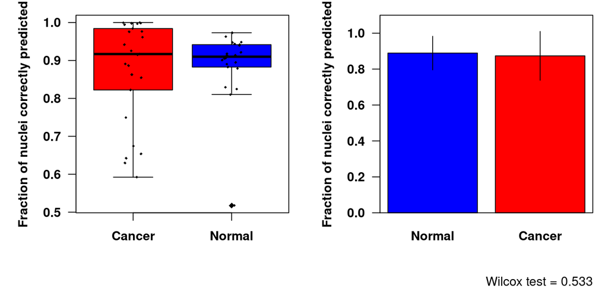

Printing Tissue level contingency table.

```
## [1] "Training"
```

```
##           Reference
## Prediction Cancer Normal
##     Cancer     19      0
##     Normal      0     17
```

```
## [1] "Test"
```

```
##           Reference
## Prediction Cancer Normal
##     Cancer      6      0
##     Normal      0      5
```

Below are some features that access the validity of the tissue level predictions.

|  | Training | Test |
| --- | --- | --- |
| Sensitivity | 1.0000000 | 1.0000000 |
| Specificity | 1.0000000 | 1.0000000 |
| Pos Pred Value | 1.0000000 | 1.0000000 |
| Neg Pred Value | 1.0000000 | 1.0000000 |
| Precision | 1.0000000 | 1.0000000 |
| Recall | 1.0000000 | 1.0000000 |
| F1 | 1.0000000 | 1.0000000 |
| Prevalence | 0.5277778 | 0.5454545 |
| Detection Rate | 0.5277778 | 0.5454545 |
| Detection Prevalence | 0.5277778 | 0.5454545 |
| Balanced Accuracy | 1.0000000 | 1.0000000 |
| AUC_ROC | 1.0000000 | 1.0000000 |

### Saving Data and Models

We have saved data and the models generated.

## Scoring nuclei from TMAs of different stages

Now that we built and validated the scoring system for two extreme conditions, we next wanted to do the same for nuclei from TMA of varying clinical stages.

Below we visualize the fraction of nuclei that are predicted as normal or cancer in the various stages.

1. We see that on average 90% of the nuclei in the tissues diagnosed as normal or hyperplasia.
2. Over 80% of the nuclei in tissues diagnosed as IDC and ILC are classified to the cancer. The above two are in line with the model used above. In addition, we have nuclei from tissues whose diagnostic class was not introduced to the model above.
3. Almost all nuclei from Fibroadenoma TMA are classified to be cancer. Fibroadenomas are benign breast tumors characterized by an admixture of stromal and epithelial tissue that develop from the lobules. Hence, it is expected that all the cells in the TMA are somehow affected and are distinct from normal cells in the tissue.
4. There is high level variability in the nuclei classification fraction for DCIS TMA with some tissues have very high fraction of predicted normal nuclei. This is expected as DCIS tissues contain cancer cells in the Duct and surrounded by normal cells and the fraction of the TMA that is occupied by the Duct is small and highly variable. This is reflected in the variability in the scoring as well. But on average most are classified as cancer and importantly, as seen below, most of the nuclei that are in the duct are classified as cancer.
5. Metastatic breast TMAs contain tissue from the the lymph node and these tissues again consists of nuclei from normal cells that reside in that organ as well as breast cancer cells that have metastasised to the node and fraction of these two cell categories will differ between TMAs. Also, given the mechanochemical environment between lymph nodes and breast tissue will be vastly different, it is expected that metastasized cancer cells will have varied nuclear and chromatin features compared to invasive cancer cells in the breast tissue, which were used to train the model. Still, we see that in majority of the TMAs, most of the nuclei are identified to be cancer cells.

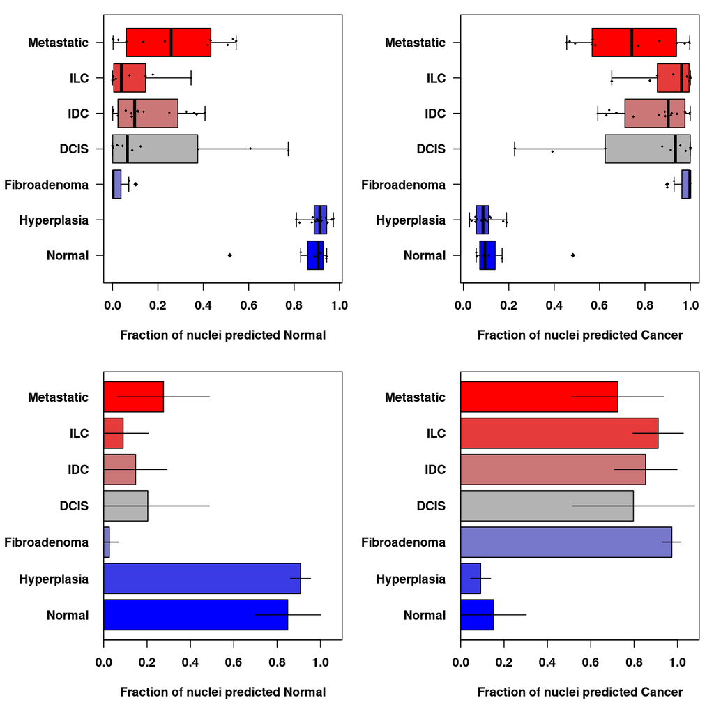

|  | Cancer | Normal | Frac_Cancer | Frac_Normal |
| --- | --- | --- | --- | --- |
| DCIS | 8 | 2 | 80.00000 | 20.00000 |
| Fibroadenoma | 7 | 0 | 100.00000 | 0.00000 |
| Hyperplasia | 0 | 15 | 0.00000 | 100.00000 |
| IDC | 16 | 0 | 100.00000 | 0.00000 |
| ILC | 9 | 0 | 100.00000 | 0.00000 |
| Metastatic | 10 | 3 | 76.92308 | 23.07692 |
| Normal | 0 | 7 | 0.00000 | 100.00000 |

Below is a histogram and a barplot (mean +/- SD) of all the nuclei from all the TMAs that belong to the different clinical stages. The distribution characteristics are summarized in a table below. We see that MGS of nuclei from normal and hyperplasia TMAs is higher. Also , the variability is highest for DCIS.

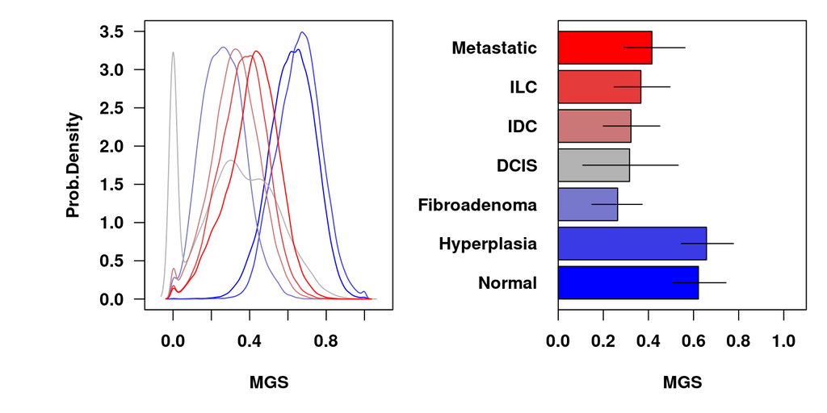

| Sample | MGS_Mean | MGS_Median | MGS_Min | MGS_Max | MGS_SD | MGS_CV | MGS_CD | MGS_IQR | MGS_QCD | MGS_FWHM |
| --- | --- | --- | --- | --- | --- | --- | --- | --- | --- | --- |
| Normal | 0.621638713006353 | 0.625765627305767 | 0 | 1 | 0.118123857675052 | 0.190020111688001 | 0.0224459086284309 | 0.0791635621572578 | 0.0594903964152229 | 0.290180135281212 |
| Hyperplasia | 0.657474312214208 | 0.661449443344456 | 0 | 1 | 0.115518378763041 | 0.175700216140771 | 0.0202966041168978 | 0.0744058089861005 | 0.0532495233261608 | 0.272615069799581 |
| Fibroadenoma | 0.263468101317719 | 0.260554122106673 | 0 | 0.733978835884342 | 0.111498901865806 | 0.423196968848038 | 0.0471859972994941 | 0.0786819740339261 | 0.131182489544183 | 0.289363912746452 |
| DCIS | 0.316296353774074 | 0.32048334332078 | 0 | 1 | 0.21157888161919 | 0.668926084966246 | 0.141530632943062 | 0.155565287857601 | 0.195303255660787 | 0.392193635895219 |
| ILC | 0.322607612466072 | 0.325240146831573 | 0 | 0.820334891310809 | 0.125345871126303 | 0.388539719097561 | 0.0487018495574527 | 0.0825123349322097 | 0.112569119679047 | 0.280314003597063 |
| IDC | 0.366587322164172 | 0.371689275842641 | 0 | 1 | 0.124068310798666 | 0.338441357072091 | 0.0419898474763425 | 0.0803408194298822 | 0.0975342115860593 | 0.297220242946093 |
| Metastatic | 0.415371784199767 | 0.426976885609869 | 0 | 1 | 0.13506077836544 | 0.325156362331256 | 0.0439158713869345 | 0.0810703793408628 | 0.0867040485449027 | 0.268976604261152 |

To make sure that the variability of the MGS from different TMAs are accounted for, we visualise the distribution of MGS for each tissue from different classes.

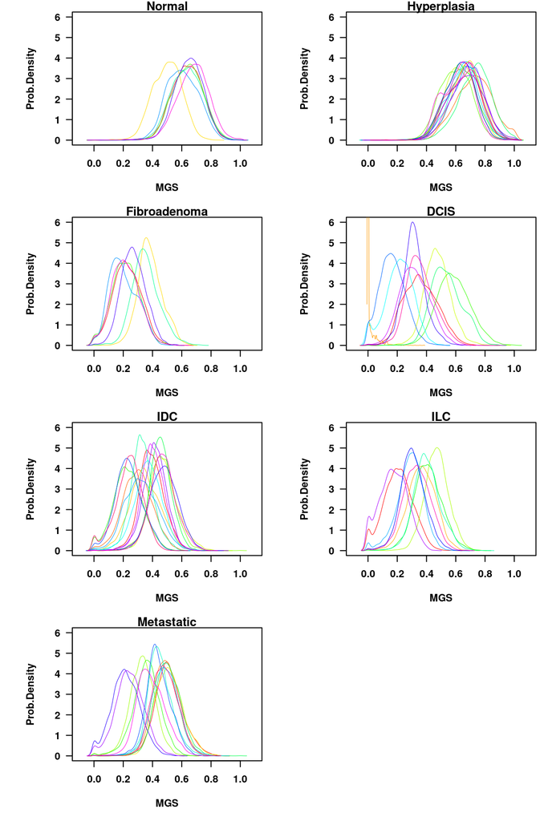

Below is a histogram and barplot of the Mean MGS nuclei of each TMA (error is SD) that belong to the different clinical stages. The distribution characteristics are summarized in a table below. We see that MGS of nuclei from normal and hyperplasia TMAs is higher. Also , the variability is highest for DCIS.

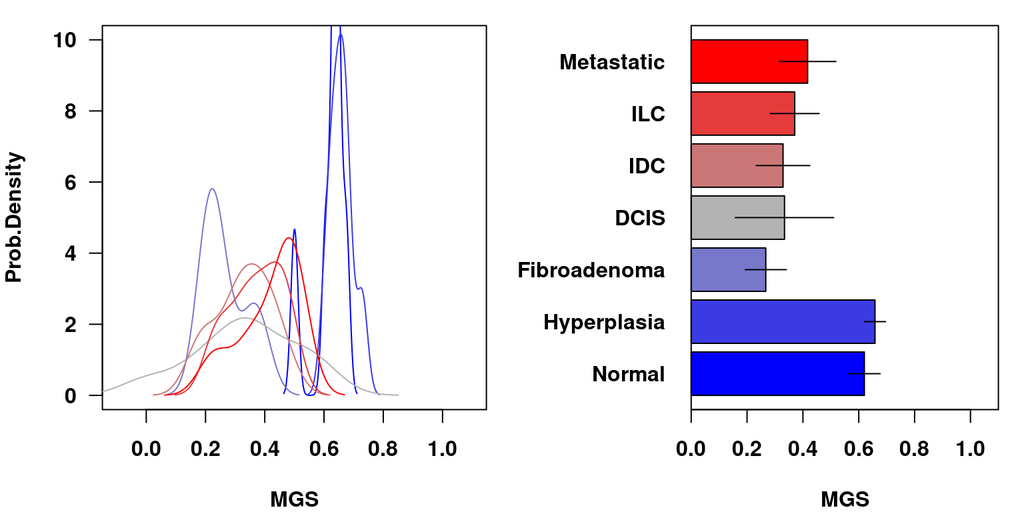

| Sample | MGS_Mean | MGS_Median | MGS_Min | MGS_Max | MGS_SD | MGS_CV | MGS_CD | MGS_IQR | MGS_QCD | MGS_FWHM | MGS_Skew | MGS_Kurtosis |
| --- | --- | --- | --- | --- | --- | --- | --- | --- | --- | --- | --- | --- |
| Normal | 0.620042447166219 | 0.637006569431122 | 0.500521325577203 | 0.67489280188587 | 0.0566435273615434 | 0.0913542735992051 | 0.00517462829621049 | 0.00835461289164252 | 0.00651498985389797 | 0.0387491457364136 | -1.49022874397957 | 4.04592336236927 |
| Hyperplasia | 0.658121508168152 | 0.653378720642715 | 0.598618663033603 | 0.730806097382395 | 0.0375834035910195 | 0.057107089077868 | 0.00214627877672182 | 0.0247644110059345 | 0.0185985764809781 | 0.0861880142888098 | 0.459406163277625 | 2.63490282335665 |
| Fibroadenoma | 0.267141000605016 | 0.22717798365747 | 0.201966820176103 | 0.38455000919195 | 0.0735522903291145 | 0.275331342484061 | 0.0202512508390925 | 0.084730350805317 | 0.157173995995231 | 0.125070913778668 | 0.760625399623007 | 1.87660941132259 |
| DCIS | 0.334096635045616 | 0.339847943382325 | 0.00275827998073674 | 0.58629936136067 | 0.176048896289743 | 0.526940046150736 | 0.0927672135357032 | 0.107098119993015 | 0.136119643862516 | 0.439469139967739 | -0.328085907712981 | 2.46769898978755 |
| ILC | 0.328928822578112 | 0.334274425795835 | 0.174562621148665 | 0.469420265002214 | 0.096183940497407 | 0.292415665320925 | 0.0281256909537375 | 0.068891673902131 | 0.0934199728934074 | 0.282268527165494 | -0.258853743803728 | 2.05492268121084 |
| IDC | 0.370701394571351 | 0.382617038207387 | 0.232335867838274 | 0.476961260655324 | 0.0875793337998376 | 0.236253046474528 | 0.0206908844184212 | 0.0721241983696287 | 0.0861330216008182 | 0.284898050436646 | -0.304006962119118 | 1.79339546379696 |
| Metastatic | 0.416870253049873 | 0.452347653911671 | 0.216469445083094 | 0.514903824531379 | 0.101259809186702 | 0.242904856956987 | 0.0245964994659877 | 0.034617783580676 | 0.0368543608062907 | 0.181633996157659 | -0.88441348082081 | 2.4567600135553 |

Visualising the Score for a DCIS TMA.

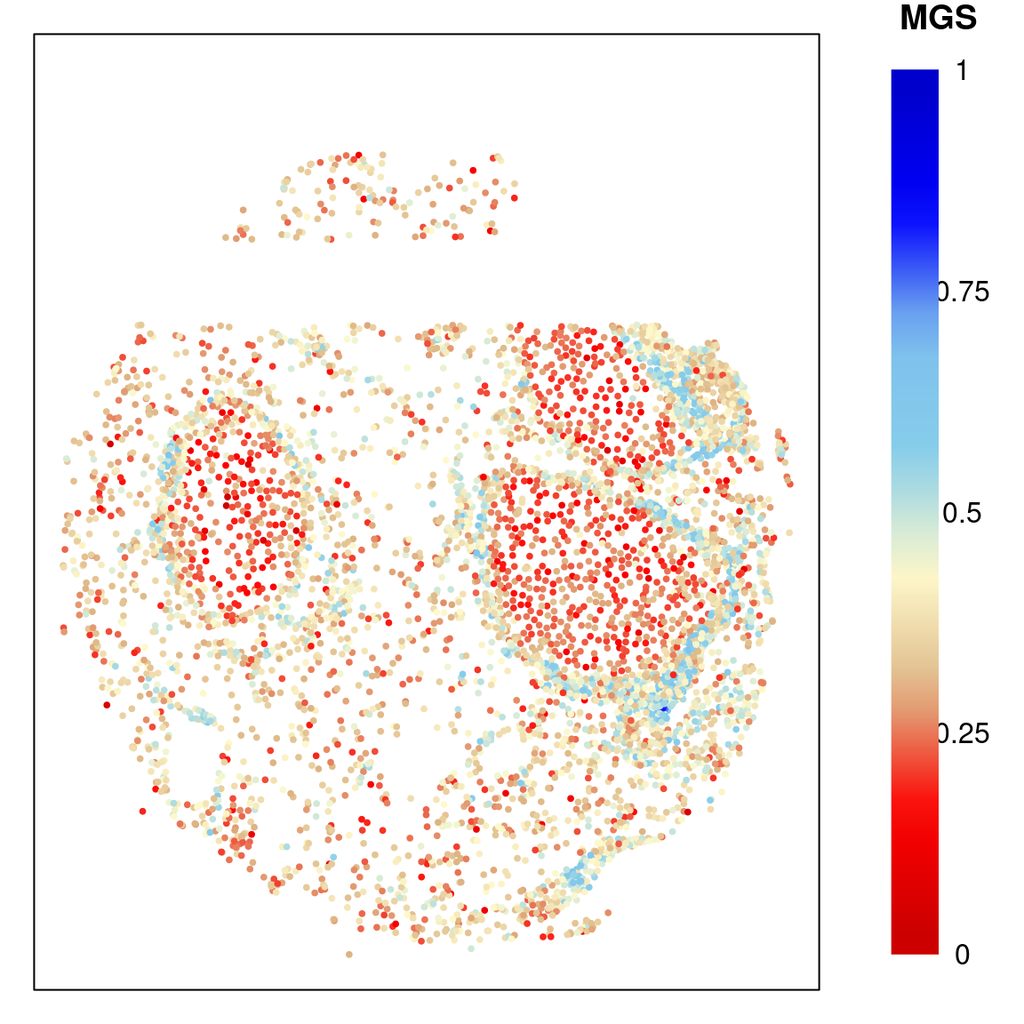

### Output Data

Save the MGS scores and tissue summary for all stages